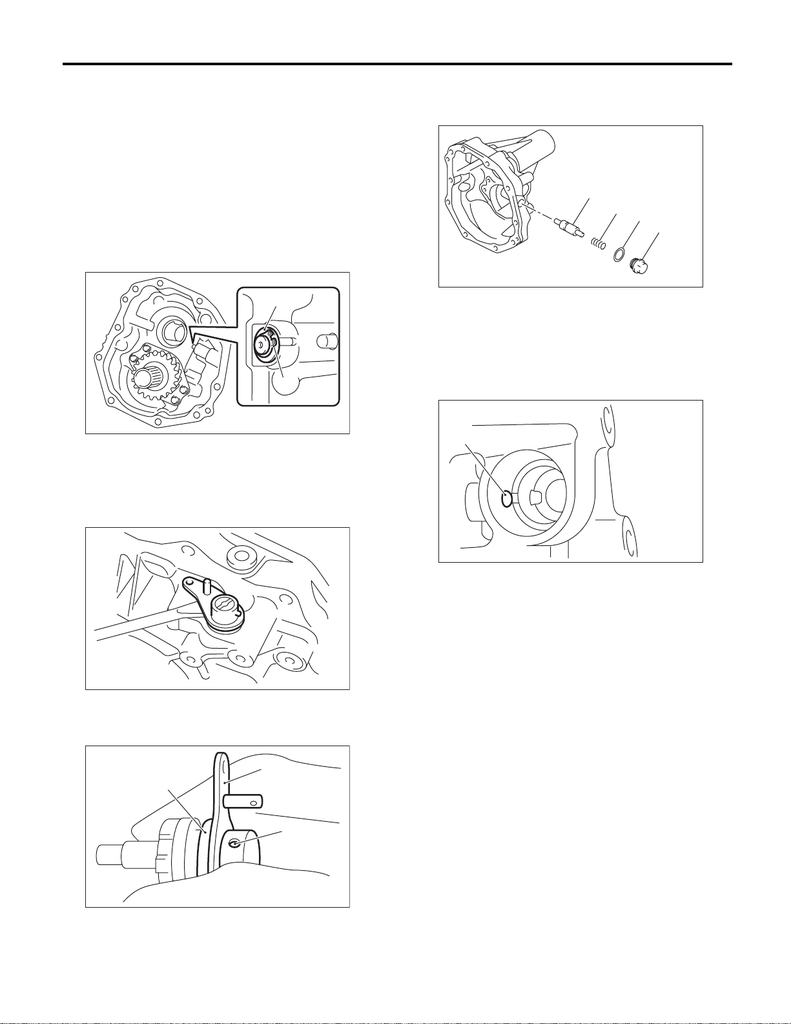

6MT(TY85)-49

Reverse Check System

MANUAL TRANSMISSION AND DIFFERENTIAL

14.Reverse Check System

A: REMOVAL

1) Remove the manual transmission assembly

from the vehicle. <Ref. to 6MT(TY85)-31, REMOV-

AL, Manual Transmission Assembly.>

2) Prepare the transmission for overhaul. <Ref. to

6MT(TY85)-38, Preparation for Overhaul.>

3) Remove the extension case. <Ref. to

6MT(TY85)-42, REMOVAL, Extension Case.>

4) Remove the snap ring and washer from the re-

verse check shaft.

5) Remove the reverse check shaft and spring from

the extension case.

6) Remove the straight pin, and remove the re-

verse check lever and oil seal from the reverse

check shaft.

7) Remove the plug from the extension case, and

remove the gasket, spring and reverse check

plunger.

8) Remove the reverse lock plunger.

(A) Snap ring

(B) Washer

(A) Straight pin

(B) Reverse check lever

(C) Oil seal

MT-00494

(A)

(B)

MT-00495

MT-00496

(A)

(C)

(B)

(A) Plug

(B) Gasket

(C) Spring

(D) Reverse check plunger

(A) Reverse lock plunger

MT-01818

(A)

(B)

(C)

(D)

MT-00498

(A)

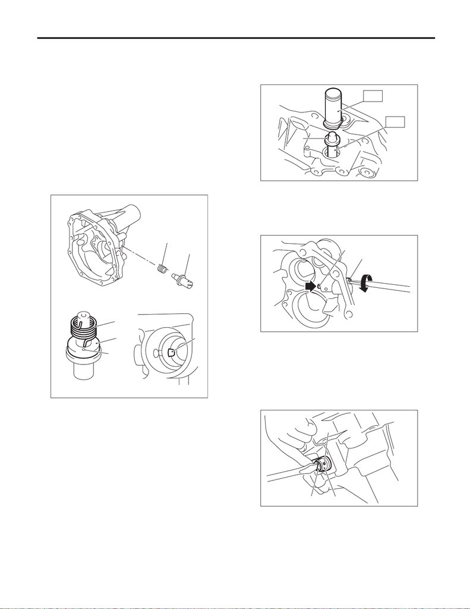

6MT(TY85)-50

Reverse Check System

MANUAL TRANSMISSION AND DIFFERENTIAL

B: INSTALLATION

1) Insert the reverse lock plunger.

2) Install the reverse check plunger, spring, gasket

and plug in order.

NOTE:

Use a new gasket.

Tightening torque:

41 N·m (4.2 kgf-m, 30.2 ft-lb)

3) Install the spring and reverse check shaft to the

extension case.

NOTE:

Confirm that the end of the spring matches the hole

of the reverse check shaft and the cut out of the ex-

tension case.

4) Install the washer and snap ring.

5) Attach ST1 to the reverse check shaft. Install the

new oil seal, and push it in using ST2.

ST1 18671AA000 OIL SEAL GUIDE

ST2 18657AA010 INSTALLER

6) Insert the reverse check lever, and turn the re-

verse check shaft until the plunger is first pushed

in.

7) Match the hole of the reverse check lever and

the reverse check shaft, and attach the straight pin.

NOTE:

Use a new straight pin.

(A) Reverse check shaft

(B) Spring

(C) Hole

(D) Cut out

(A)

(A)

(C)

(D)

(B)

(B)

MT-00499

(A) Oil seal

(A) Plunger

(B) Reverse check shaft

(A) Reverse check shaft

(B) Reverse check lever

(C) Hole

MT-00500

(A)

ST2

ST1

MT-00501

(A)

(B)

MT-00502

(A)

(B)

(C)

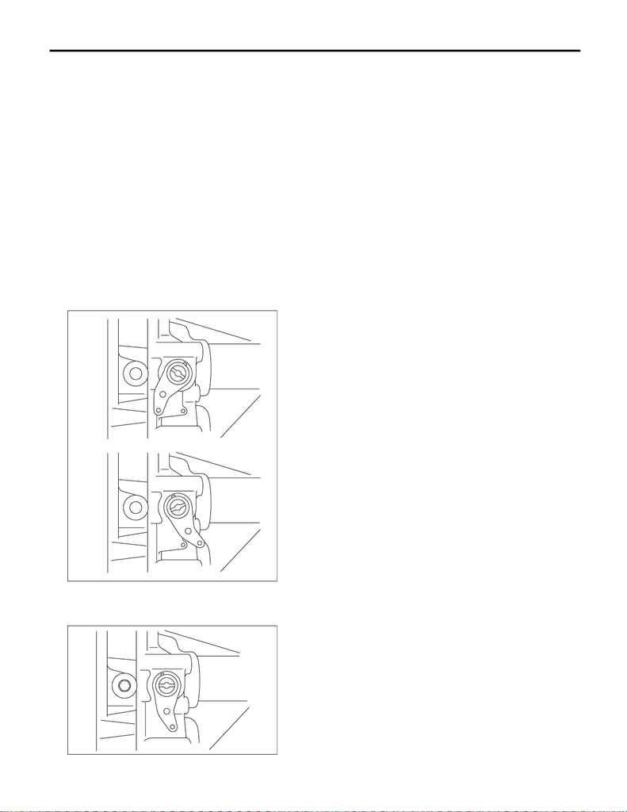

6MT(TY85)-51

Reverse Check System

MANUAL TRANSMISSION AND DIFFERENTIAL

8) Check that the reverse check is operating cor-

rectly. <Ref. to 6MT(TY85)-51, INSPECTION, Re-

verse Check System.>

9) Install the extension case. <Ref. to 6MT(TY85)-

42, INSTALLATION, Extension Case.>

10) Install the manual transmission assembly to the

vehicle. <Ref. to 6MT(TY85)-33, INSTALLATION,

Manual Transmission Assembly.>

C: INSPECTION

1) Check that there is no damage on any parts.

2) Check that the reverse check lever is operating

smoothly.

3) Inspect that there is no oil leak at the oil seal sec-

tion of the reverse check shaft. If there is oil leak-

age, replace the oil seal.

4) Check the operation of the reverse check.

(1) When the reverse check lever is in the fol-

lowing position, the plunger is pressed, or the

gear can shift into reverse.

(2) When the reverse check lever is in the fol-

lowing position, the plunger is not pressed, or

the gear cannot shift into reverse.

5) If it is not as specified, reassemble the reverse

check system.

MT-00503

MT-00504